# Chap 12 - Basic Multilevel Modeling

Bryan White

December 9, 2015

## Can Be thought of in two ways:

1. A generalization of regression where intercepts and slopes are allowed to vary by group
2. A regression with a categorical input variable representing group membership

Most important here is in multilevel modeling, each level of the group is given a model, this group level model is estimated simultaneously with the overall model. So each coefficient has a model and that is fit along with the data level model.

## 12.2 Partial Pooling with no predictors

In this section we discuss the radon homes example and compare partial pooling to complete and no pooling methods

Complete Pooling - In the radon example this would be to say that all counties are the same and that county level effects do not matter. Thus the prediction would be the average across all counties

Partial Pooling - In the radon example this would be saying there is a different average radon level for each county

*Lets Quickly look at some Complete Pooling versus partial Pooliong in* [STAN!](https://github.com/tbwhite2/BayesianBookClub/blob/master/12.3_PartialPoolingWithPredictors.R)

Complete Pooling of the estimates ignores the variation between counties while no pooling overstates it.

**So partial pooling is especially important when:**

1. There are a whole bunch of levels, and some may not be different from others
2. There are varying amounts of data collected for each group - such that groups with small amounts of data can still be used.

Multilevel Models are a compromise between the two extremes!

In partial pooling averages from counties with a smaller sample size carry less information and the weighting pulls the estimate closer to the overall average. Thus partial pooling becomes like a weighted average to reflect the relative amount of information available about the individual county

As the county (group) becomes infinitely large, the multilevel estimate approaches the group average, conversely, as the group approaches 0, the estimate approaches the overall average

To actually apply these weights we need information on the the variation within and between counties. In practice, we use lmer() or STAN to do that

## 12.3 Partial Pooling with Predictors

This section considers partial pooling for a model with unit-level predictors

Figure 12.2 shows the log home radon measurement vs floor of measurement

### Fig 12.2

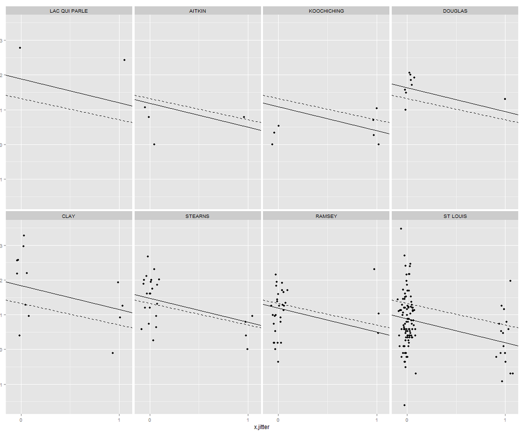

This is what we would expect, though on pg 256, he says that the difference can be seen between the partial pooling and no pooling most in Stearns and Ramsey counties, yet these have the most similar estimates?

## Multilevel Analysis

In a multilevel model, a soft constraint is applied to the coefficients of the predictors that they have an assigned probability distribution informed by the data. This has the effect of pulling the estimate toward the overall mean.

This is different from the hard constraint imposed by the no pooling model which defines each parameter by OLS (fitting intercepts in a model run separately for each county)

As the group standard deviation gets large the pooling is reduced and as the group level standard deviation gets small the estimates are pulled to 0, yielding the complete pooling estimate. Thus when there is a large difference between groups, we don’t pool much

### Fig 12.4

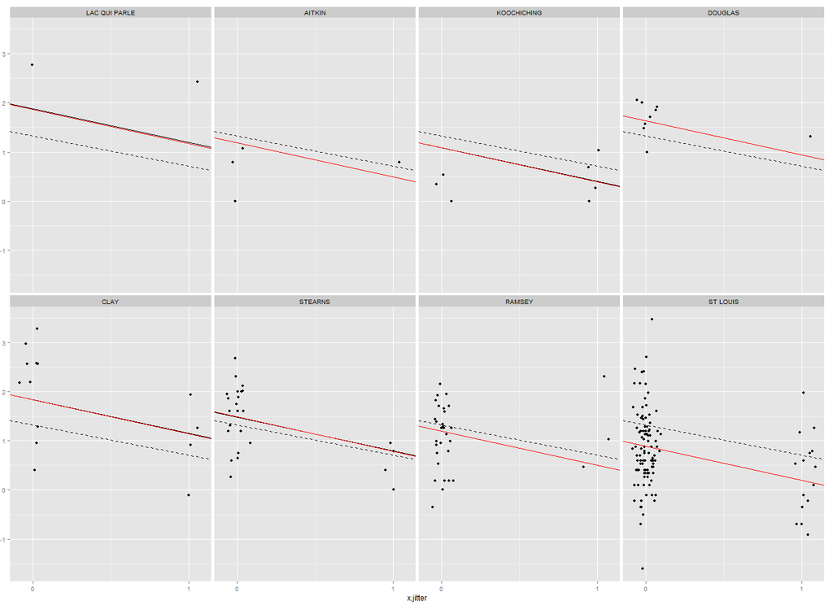

Very similar to the previous plot, he uses the [lmer()](https://cran.r-project.org/web/packages/lme4/lme4.pdf) function to do replicate this plot, not sureif there is a way to do the same in STAN

his method (and my wonderful comments) are [here](https://github.com/tbwhite2/BayesianBookClub/blob/master/12.4_FittingMLMinR.R)

## Interpretation/diagnostics

Hyperparameters - those model parameters without group level subscripts. These would include things like the overall regression line and the error standard deviations for the individual and county level

Intra Class Ratio This is the variance at the group level divided by the sum of the variance at the group and individual level. The number will range between 0-1 with 1 meaning all members of the group are identical.

In the radon example, for a county with a sample size less than 5, there is more information at the complete pooling level than at the county level. This means that counties with samples greater than 5 will be further from the pooling estimate than those with less.

Classical regression comparison - Classical regression can be thought of as a special case of multilevel modeling (haha) as the standard deviation between groups gets small we approach complete pooling, and as it gets larger we approach no pooling

If we have time, lets look at the group level parameters problem incorporating county [uranium](https://github.com/tbwhite2/BayesianBookClub/blob/master/12.6_Group-LevelPredictors.R) levels